# Prediction Assignment

5/16/2021

# Executive Summary

In this project we will build a prediction model from data on barbell lifts done correctly and incorrectly in 5 different ways by 6 participants. The goal of the project is to predict the manner in which they did the exercise with the prediction outcome being the variable “classe” in the training set.This project will determine which of the other variables to predict with and will then use the prediction model to predict 20 different test cases.

```r
library(caret)
```

```r
library(corrplot)
training<-read.csv("https://d396qusza40orc.cloudfront.net/predmachlearn/pml-training.csv",na.strings=c("NA","","#DIV/0!"))

quiz_set<-read.csv("https://d396qusza40orc.cloudfront.net/predmachlearn/pml-testing.csv",na.strings=c("NA","","#DIV/0!"))
```

## Cleaning the Data

Here we will remove informational variables as well as those with zero variance across samples as they are not useful for prediction.

```r
training2<-training[,-c(1:7)] #filter out informational cols since they are not needed for model prediction

#remove near zero variance variables. that is, variables that are constant/near constant across samples
nzv <- nearZeroVar(training2)
training3 <- training2[ , -nzv]
```

Here, our standard treatment for NA’s is to remove variables that have them. However, this may not be the best method with a better method being imputation.

```r
#Remove variables that are  NA.
na_var <- sapply(training3, function(x) sum(is.na(x)))
# alt. apply(training3,2, function(x) sum(is.na(x)))>0 and then do == FALSE, or do it like with ==0

training4 <- training3[ , na_var == 0]  #alt. training3[,colSums(is.na(training2)) == 0] . NOTE : complete.cases is for ROWS NOT COLS (i.e variables)
```

## Correlation Matrix

A quick visualization is done to see how the variables correlate. The AOE (Angular Order of Eigenvectors) method is used, which orders based on variable similarity calculated as the angular distance between variables on an eigenvector plot.

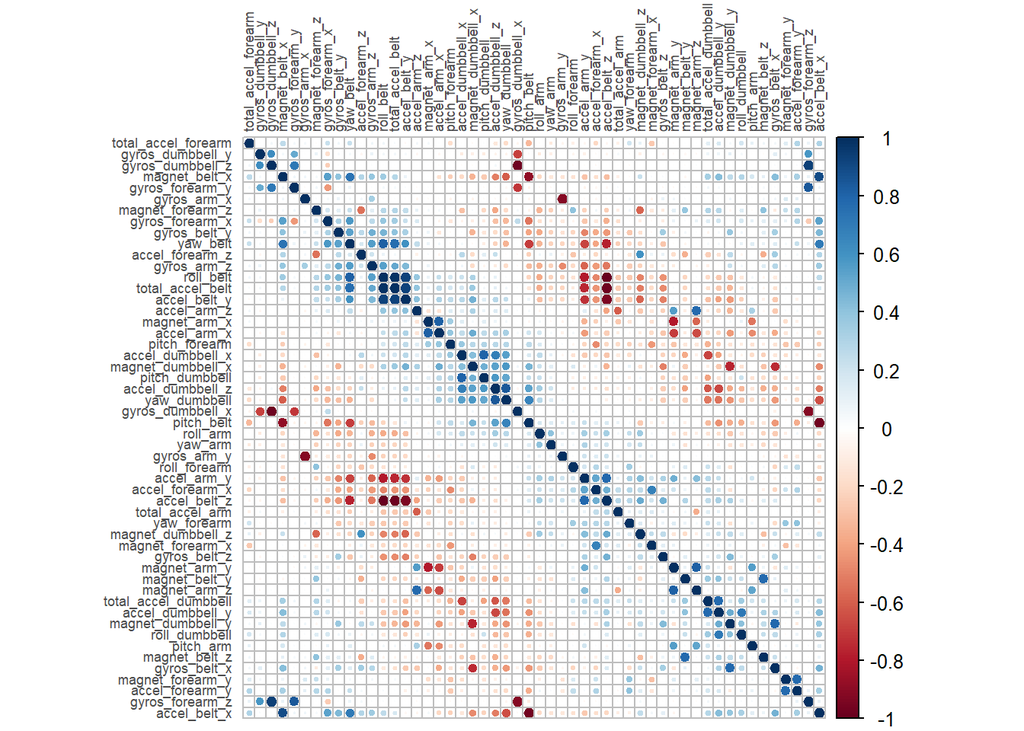

```r
corr_mat <- cor(training4[ , -53])
#AOE : angles between vectors on an eigenvector plot approximate correlations
#so an ordering based on the angular positions of these vectors naturally places the most similar variables contiguously.
corrplot(corr_mat, order = "AOE", method = "circle", type = "full", tl.cex = 0.55, tl.col = rgb(.3, .3, .3))
```

## Model Fit

Here we fit the model using random forest since these models are known for their very high accuracy. We use k-fold cross-validation method as a resampling method

```r
#fit a random forest model with cross-validation

fit<-train(classe ~ .,method="rf",data=training4, trControl = trainControl(method = "cv"))

fit$finalModel
```

```
##
## Call:
##  randomForest(x = x, y = y, mtry = param$mtry)
##                Type of random forest: classification
##                      Number of trees: 500
## No. of variables tried at each split: 2
##
##         OOB estimate of  error rate: 0.43%
## Confusion matrix:
##      A    B    C    D    E  class.error
## A 5577    2    0    0    1 0.0005376344
## B   14 3779    4    0    0 0.0047405847
## C    0   13 3405    4    0 0.0049678551
## D    0    0   38 3176    2 0.0124378109
## E    0    0    0    6 3601 0.0016634322
```

```r
pred<-predict(fit,quiz_set) #note to self: no need to do anything to quiz DS because model only uses variables from the quiz DS on which it was built in the training DS
pred
```

```
##  [1] B A B A A E D B A A B C B A E E A B B B
## Levels: A B C D E
```

```r
varImp(fit)
```

```
## rf variable importance
##
##   only 20 most important variables shown (out of 52)
##
##                   Overall
## roll_belt          100.00
## yaw_belt            80.14
## magnet_dumbbell_z   70.59
## pitch_belt          62.64
## magnet_dumbbell_y   62.52
## pitch_forearm       59.20
## roll_forearm        52.84
## magnet_dumbbell_x   50.32
## accel_belt_z        46.82
## accel_dumbbell_y    46.07
## magnet_belt_z       41.72
## roll_dumbbell       41.17
## magnet_belt_y       40.58
## accel_dumbbell_z    37.24
## roll_arm            34.69
## accel_forearm_x     32.73
## yaw_dumbbell        29.30
## gyros_belt_z        28.94
## accel_dumbbell_x    28.13
## magnet_forearm_z    28.08
```

## Conclusion

The random forest model produces a very high accuracy prediction. The OOB is very low.